# Lab 6 Key

Prof. Amanda D. Perez, PhD

# Logistic Regression: Titanic Data

```r
library(tidyverse)
library(sjlabelled)
library(haven)
library(knitr)
library(broom)
library(dplyr)
library(viridis)
```

For this section you are going to run and interpret a logistic regression on real data on Titanic survival rates. Specifically, you will be looking at how Sex, Age, and Passenger Class impact survival odds.

Run the below code chunk to load the data and glimpse it.

```r
titanic <- read.csv("Data/titanic.csv")

titanic <- titanic %>%
  select(c("Survived", "Sex", "Pclass", "Age"))


glimpse(titanic)
```

```
## Rows: 891
## Columns: 4
## $ Survived <int> 0, 1, 1, 1, 0, 0, 0, 0, 1, 1, 1, 1, 0, 0, 0, 1, 0, 1, 0, 1, 0…
## $ Sex      <chr> "male", "female", "female", "female", "male", "male", "male",…
## $ Pclass   <int> 3, 1, 3, 1, 3, 3, 1, 3, 3, 2, 3, 1, 3, 3, 3, 2, 3, 2, 3, 3, 2…
## $ Age      <dbl> 22, 38, 26, 35, 35, NA, 54, 2, 27, 14, 4, 58, 20, 39, 14, 55,…
```

We will convert *Survived* and *Pclass* to labeled factors to facilitate interpretation and the construction of graphs. Run the below graphs and do not make any changes.

```r
titanic$Sex <-  as.factor(titanic$Sex)

titanic <- titanic %>%
  mutate(survived_factor = factor(Survived,
                                levels = 0:1,
                                labels = c("Drowned", "Survived")),
         class_factor   = factor(Pclass,
                                levels = 1:3,
                                labels = c("first",
                                           "second",
                                           "third")))
```

## Titanic Data Visualization

The first step in any statistical analysis should be to perform a visual inspection of the data in order to check for coding errors, outliers, or funky distributions.

The variable *Survived* is the dependent variable. We can check the distribution of responses using the count function:

```r
titanic %>%
  count(survived_factor) %>%
  mutate(prop = prop.table(n)) %>%
  kable(align = c("l","c","c"),
        col.names = c("Survived", "N", "Proportion"),
        digits = 3)
```

| Survived | N | Proportion |
| --- | --- | --- |
| Drowned | 549 | 0.616 |
| Survived | 342 | 0.384 |

Now we will review the distribution for the other categorical variables, *Sex* and *Class*

```r
titanic %>%
  count(Sex) %>%
  mutate(prop = prop.table(n))%>%
  kable(align = c("l","c","c"),
        col.names = c("Sex", "N", "Proportion"),
        digits = 3)
```

| Sex | N | Proportion |
| --- | --- | --- |
| female | 314 | 0.352 |
| male | 577 | 0.648 |

```r
titanic %>%
  count(class_factor) %>%
  mutate(prop = prop.table(n))%>%
  kable(align = c("l","c","c"),
        col.names = c("Class", "N", "Proportion"),
        digits = 3)
```

| Class | N | Proportion |
| --- | --- | --- |
| first | 216 | 0.242 |
| second | 184 | 0.207 |
| third | 491 | 0.551 |

We can also check out the distribution of age. We will create a table of summary statistics using the summarise function.

```r
titanic %>%
  summarise(Min    = min(Age, na.rm = T),
            Max    = max(Age, na.rm = T),
            Median = median(Age, na.rm = T),
            Mean   = mean(Age, na.rm = T),
            SD     = sd(Age, na.rm = T)) %>%
  mutate_all(~round(., 3)) %>%
  kable(align = rep("c", 4))
```

| Min | Max | Median | Mean | SD |
| --- | --- | --- | --- | --- |
| 0.42 | 80 | 28 | 29.699 | 14.526 |

## Exercise 1: Values

What is the minimum value? .42

What is the maximum value? 80

What is the median value? 28

What is the mean value? 29.699

What is the standard deviation? 14.53

Tables are useful, but often graphs are more informative. Bar graphs are the easiest for examining categorical variables. Start with the outcome variable.

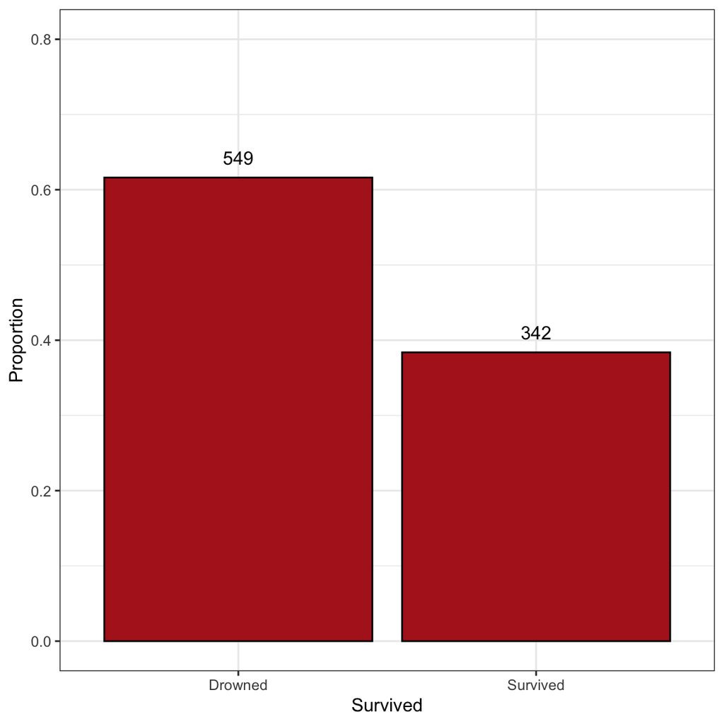

```r
titanic %>%
  ggplot(aes(x=survived_factor, y = ..prop.., group = 1)) +
  geom_bar(fill = 'firebrick', color = 'black') +
  geom_text(stat='count', aes(label=..count..), vjust=-1) +
  xlab("Survived") +
  ylab("Proportion") +
  ylim(0,.8) +
  theme_bw()
```

## Exercise 2: Describe the trend you see above.

ANSWER: More people drowned (versus survived) the titanic.

Now the categorical independent variables.

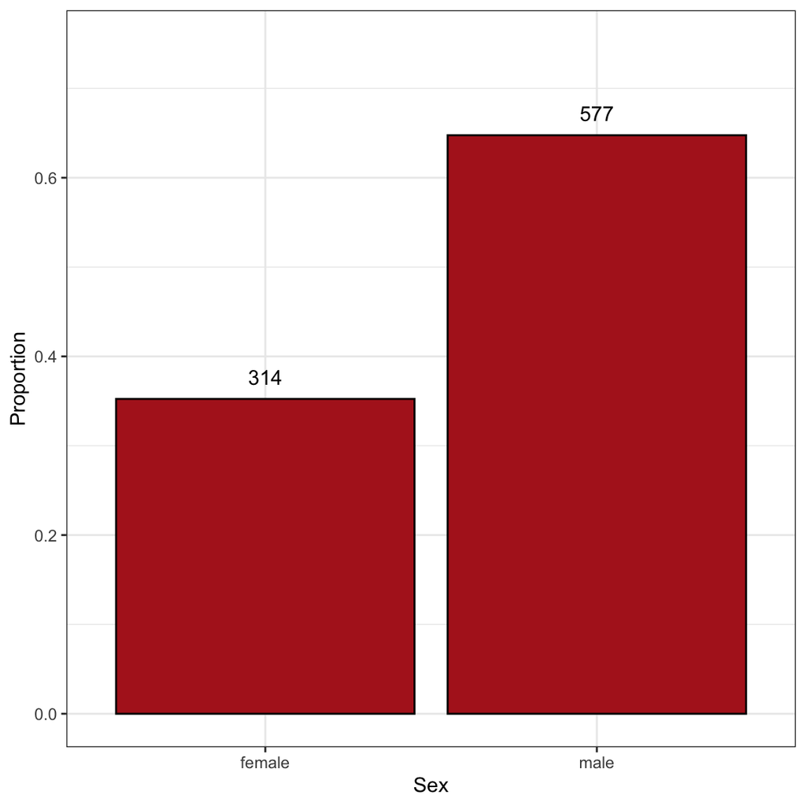

```r
titanic %>%
  ggplot(aes(x=Sex, y = ..prop.., group = 1)) +
  geom_bar(fill = 'firebrick', color = 'black')  +
  geom_text(stat='count', aes(label=..count..), vjust=-1) +
  xlab("Sex") +
  ylab("Proportion") +
  ylim(0,.75) +
  theme_bw()
```

## Exercise 3: Describe the trend you see above.

ANSWER: There were a lot more males on the boat.

## Exercise 4: Produce a bar plot for the Ticket Class variable (Pclass) and describe the trend you see.

Re-create the same plots from the previous examples (colors, axes, proportion, labels) but with the ticket class variable. Interpret what you see. *Hint: Copy and paste code from a previous geom_bar() and edit the variable name/labels.*

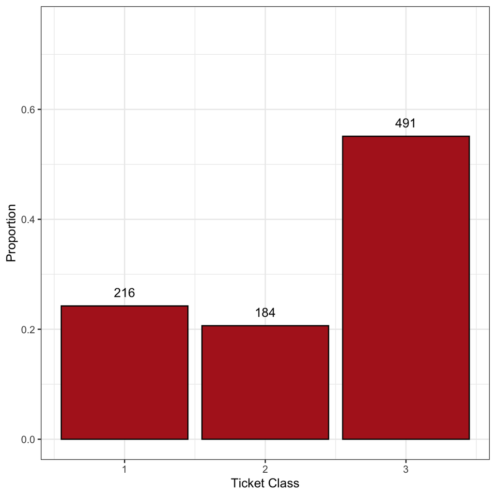

```r
titanic %>%
  ggplot(aes(x=Pclass, y = ..prop.., group = 1)) +
  geom_bar(fill = 'firebrick', color = 'black')  +
  geom_text(stat='count', aes(label=..count..), vjust=-1) +
  xlab("Ticket Class") +
  ylab("Proportion") +
  ylim(0,.75) +
  theme_bw()
```

ANSWER: The majority of passengers were 3rd class.

For continuous variables, histograms allow us to determine the shape of the distribution and look for outliers. The following command produces the histogram.

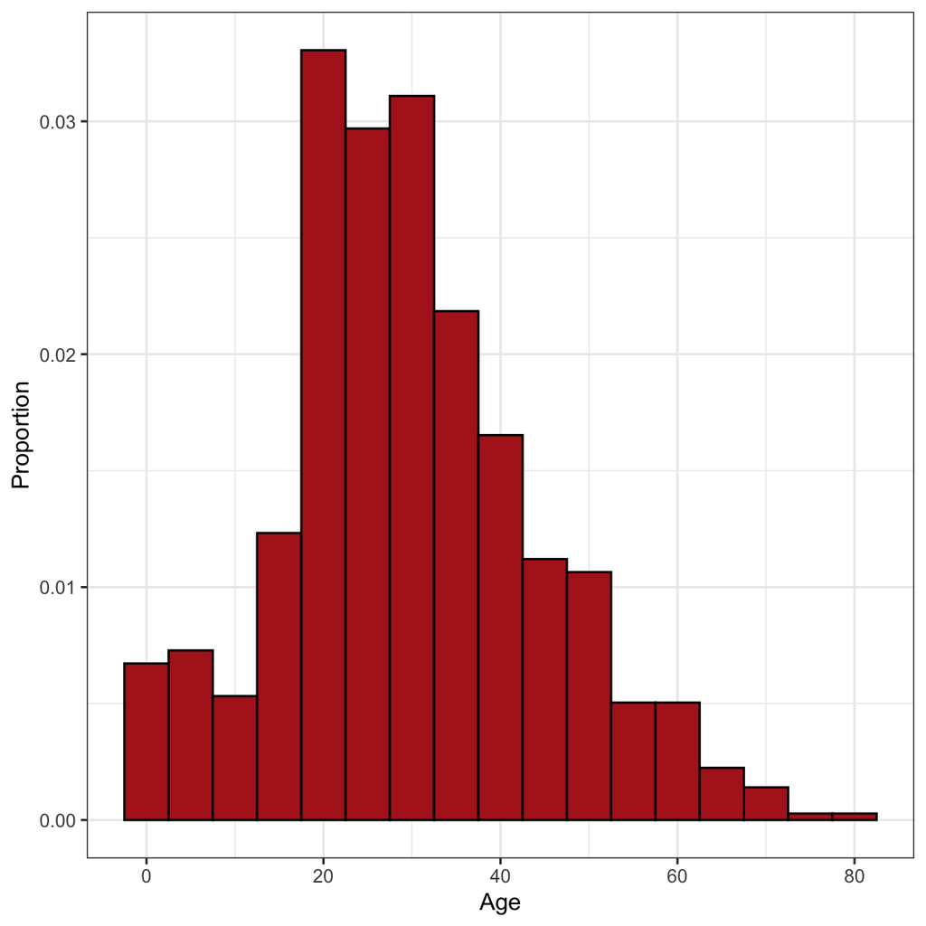

```r
titanic %>%
  ggplot(aes(x=Age, y = ..density.., group = 1)) +
  stat_bin(binwidth = 5,  fill = 'firebrick', color = 'black') +
  xlab("Age") +
  ylab("Proportion") +
  theme_bw()
```

## Exercise 5: Describe the trend you see above.

ANSWER: The passengers center around their 20s, and there are not a lot of passengers over 60.

Prior to moving on to the fully specified model, it is advisable to first examine the simple associations between the outcome and each individual predictor. Doing so can help avoid surprises in the final model. For example, if there is no simple relationship apparent in the data, we shouldn’t be taken aback when that predictor is not significant in the model.

Graphs are again helpful. When the outcome is categorical and the predictor is also categorical, a grouped bar graph is informative. The following is the graph of survival and sex.

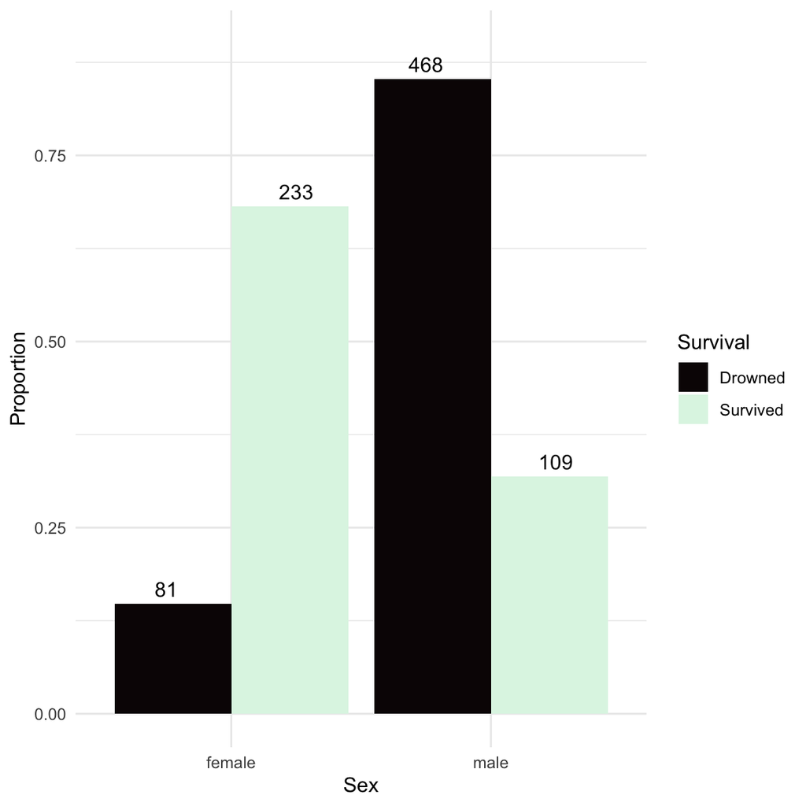

```r
titanic %>%
  ggplot(aes(x=Sex,
             y = ..prop..,
             group = survived_factor,
             fill = survived_factor)) +
  geom_bar( position = 'dodge') +
  geom_text(stat='count',
            aes(label=..count..),
            vjust=-.5,
            position = position_dodge(width = 1))+
  xlab("Sex") +
  ylab("Proportion") +
  ylim(0,.9) +
  labs(fill = "Survival") +
  scale_fill_viridis(option = "mako", discrete = TRUE) +
  theme_minimal()
```

## Exercise 6: Describe the trend you see above.

ANSWER: More females survived and more males drowned.

## Exercise 7: Produce a bar plot for the Ticket Class variable (Pclass) and describe the trend you see.

Create a similar figure as the previous example for ticket class `Pclass` (i.e., display proportions of survived and drowned within each level of ticket class). Interpret what you see.

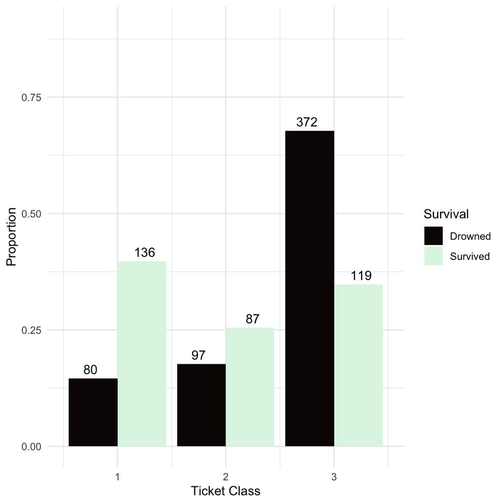

```r
titanic %>%
  ggplot(aes(x=Pclass,
             y = ..prop..,
             group = survived_factor,
             fill = survived_factor)) +
  geom_bar( position = 'dodge') +
  geom_text(stat='count',
            aes(label=..count..),
            vjust=-.5,
            position = position_dodge(width = 1))+
  xlab("Ticket Class") +
  ylab("Proportion") +
  ylim(0,.9) +
  labs(fill = "Survival") +
  scale_fill_viridis(option = "mako", discrete = TRUE) +
  theme_minimal()
```

ANSWER: For class 1, more survived versus drowned. When we get to class 3, this flips and we see more drowned versus survived.

Boxplots are useful for examining the association between a categorical variable and a variable measured on an interval scale.

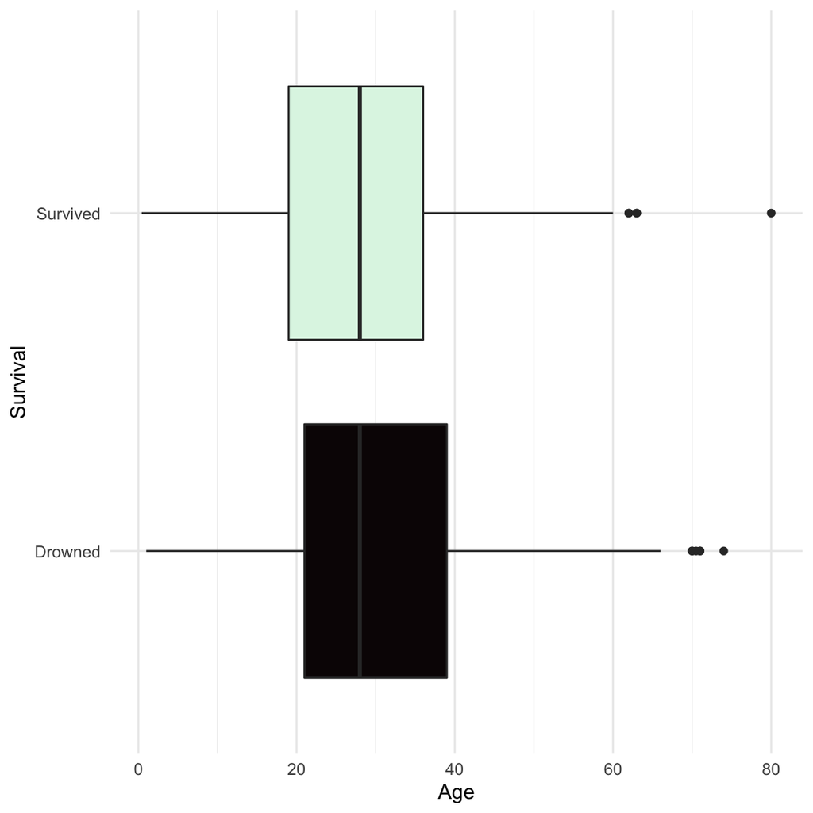

```r
titanic %>%
  ggplot(aes(x = survived_factor,
             y = Age,
             group = survived_factor,
             fill = survived_factor)) +
  geom_boxplot() +
  coord_flip() +
  ylab("Age") +
  xlab("Survival") +
  guides(fill = "none") +
  scale_fill_viridis(option = "mako", discrete = TRUE) +
  theme_minimal()
```

The coord_flip() function is used to keep the dependent variable on the y-axis.

## Exercise 8: Describe the trend you see above.

ANSWER: There doesn’t seem to be a huge distinction in age differences for survival versus drowning. Those who drowned do seem slightly older than those who survived.

Having carefully reviewed the data, we can now move to estimating the model.

**Fitting the Model**

To fit a logistic regression in R, we will use the glm function, which stands for Generalized Linear Model. Within this function, write the dependent variable, followed by ~, and then the independent variables separated by +’s. When the family is specified as binomial, R defaults to fitting a logistic regression model. Note that we are also treating Pclass as a numeric variable here. Note that 0 = drowned and 1 = survived.

## Exercise 9: Running the model

Fill in the blanks below to put the appropriate DV: `survived_factor`, IVs: `Sex + Pclass + Age`, and `family = binomial`

```r
#creating the logistic regression model called mod_log
mod_log <-  titanic %>%
  glm(formula = survived_factor ~ Sex + Pclass + Age, family = binomial)
```

Below, inside of `tidy()` add: `exponentiate = T, conf.int = T`

```r
#exponentiation of the model and outputting a table
mod_log %>%
  tidy(exponentiate = T, conf.int = T) %>%
  mutate_if(is.numeric, ~ round(.,3)) %>%
  kable(align = c("l", rep("c", 6)))
```

| term | estimate | std.error | statistic | p.value | conf.low | conf.high |
| --- | --- | --- | --- | --- | --- | --- |
| (Intercept) | 156.962 | 0.502 | 10.069 | 0 | 60.417 | 433.656 |
| Sexmale | 0.080 | 0.207 | -12.168 | 0 | 0.053 | 0.120 |
| Pclass | 0.276 | 0.139 | -9.253 | 0 | 0.208 | 0.360 |
| Age | 0.964 | 0.008 | -4.841 | 0 | 0.949 | 0.978 |

The broom package contains useful functions, like `tidy()`, for viewing the output from common models. The `conf.int = T` argument requests confidence intervals.

Because `Sex` is a factor variable, R will automatically create dummy variables for us. `Pclass` is an ordered categorical variable, we opt here to treat its effect as linear. The last variable is `age`. We find that `Sex`, `age`, and `PClass` have significant effects.

We look at our results in terms of odds ratios by setting `exponentiate = T` in the tidy() function.

This will produce a table where:

- estimate is the odds ratio
- std.error is the standard error of the odds ratio
- statistic is the z-statistic
- p.value is the significance
- conf.low is the lower level of the 95% confidence interval for the odds ratios
- conf.high is the upper level of the 95% confidence interval for the odds ratios

**Interpretation of Odds Ratios**

*An odds ratio less than one means that an increase in x leads to a decrease in the odds that y=1.*

*An odds ratio greater than one means that an increase in x leads to an increase in the odds that y=1.*

## Exercise 10: Interpret the Significant Odds Ratios from the table above.

ANSWER:

Males, compared to females, have a decreased odd of .08 of surviving.

As ticket class increases, passengers have an decreased off of surviving by .28.

As Age increases, passengers have a decreased odd of .96 of surviving.

In general, the percent change in the odds given a one-unit change in the predictor can be determined as:

**% Change in Odds=100(OR-1)**

For example, the odds of surviving are 100(.08-1) = -92% lower for males compared to females.

## Exercise 11: Calculating % change in odds for Pclass

Your job is to use the % change in odds formula to see and interpret whether there is an increase or decrease in odds of surviving (and what the percentage is) for the Pclass Odds Ratio. (Replace the ‘X’ below with the correct term from the model output above)

```r
#  % Change in Odds=100(OR-1)
100 * (.28 - 1)
```

```
## [1] -72
```

ANSWER: The odds of surviving are 100(.28-1) = -72% lower as ticket class increases.

## Exercise 12: Calculating % change in odds for Age

Your job is to use the % change in odds formula to see and interpret whether there is an increase or decrease in odds of surviving (and what the percentage is) for the Age OR. (Replace the ‘X’ below with the correct term from the model output above)

```r
#  % Change in Odds=100(OR-1)

100 * (.96 - 1)
```

```
## [1] -4
```

ANSWER: The odds of surviving are 100(.96-1) = -4% lower as age increases.

# Bootstrapping the Mean IMDB Rating

We will be using data from The Office.

Specifically, we will use `theoffice` data from the [**schrute**](https://bradlindblad.github.io/schrute/) package to estimate mean IMDB scores for episodes of The Office.

First, let’s load our packages.

```r
library(tidyverse)
library(tidymodels)
library(schrute)
library(lubridate)
library(psych)
```

There are many things we can bootstrap but the goal for this first exercise will be to bootstrap the mean `imdb_rating`.

Below are the steps for bootstrapping:

1. Take a bootstrap sample - a random sample taken with replacement from the original sample, of the same size as the original sample
2. Calculate the bootstrap statistic - a statistic such as mean, median, proportion, slope, etc. computed on the bootstrap samples
3. Repeat steps (1) and (2) many times to create a bootstrap distribution - a distribution of bootstrap statistics
4. Calculate the bounds of the XX% confidence interval as the middle XX% of the bootstrap distribution

## Exercise 1

```r
set.seed(8888)
# save resulting bootstrap distribution
office_boot <- theoffice %>%
  # specify the variable of interest
  specify(response = imdb_rating) %>%
  # generate 50 bootstrap samples
  generate(reps = 50, type = "bootstrap") %>%
  # calculate the mean of each bootstrap sample
  calculate(stat = "mean")
```

## Exercise 2

How many observations are there in `office_boot`? What does each observation represent?

```r
glimpse(office_boot)
```

```
## Rows: 50
## Columns: 2
## $ replicate <int> 1, 2, 3, 4, 5, 6, 7, 8, 9, 10, 11, 12, 13, 14, 15, 16, 17, 1…
## $ stat      <dbl> 8.299935, 8.305144, 8.308591, 8.299831, 8.301054, 8.301135, …
```

ANSWER: Each observation represents a bootstrapped mean

## Exercise 3

Visualize the bootstrap distribution. Below I have created a basic histogram. Your job is to: Add a theme, use both `color` and `fill` within the `geom_histogram()` function (see links for help), set the histogram `alpha = 0.5`, add a `geom_vline()` that has the value of the mean `office_boot$stat` and give it a `color` (see links below for help), Add a title, make the x axis say `Mean`, and finally make the y axis say `Frequency`.

[**Histogram Help**](http://www.sthda.com/english/wiki/ggplot2-histogram-plot-quick-start-guide-r-software-and-data-visualization#change-histogram-plot-line-types-and-colors)

[**Adding a Vertical Line Help**](https://www.rdocumentation.org/packages/ggplot2/versions/0.9.1/topics/geom_vline)

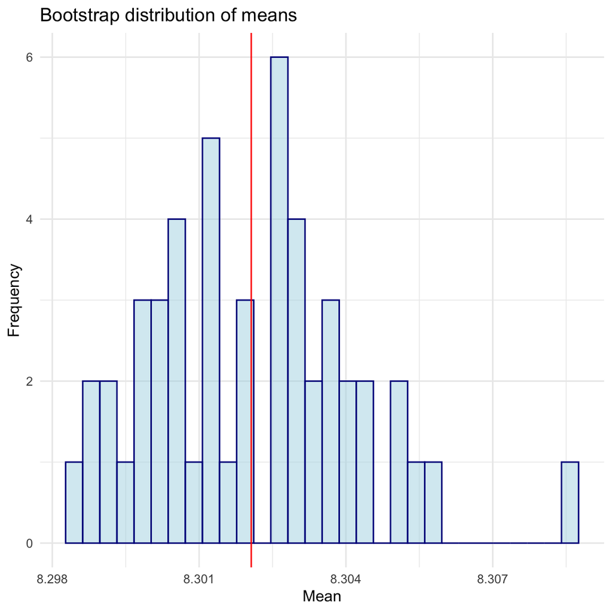

```r
ggplot(data = office_boot, mapping = aes(x = stat)) +
  geom_histogram(color="darkblue", fill="lightblue", alpha = 0.5) +
  geom_vline(xintercept = mean(office_boot$stat), color ="red")+
labs(title = "Bootstrap distribution of means", x = "Mean", y = "Frequency") +
  theme_minimal()
```

## Exercise 4

Calculate the confidence interval. A 95% confidence interval is bounded by the middle 95% of the bootstrap distribution. Fill in the values below.

```r
office_boot %>%
  summarize(lower = quantile(stat, 0.025),
            upper = quantile(stat, 0.975))
```

```
## # A tibble: 1 × 2
##   lower upper
##   <dbl> <dbl>
## 1  8.30  8.31
```

## Exercise 5

Copy and paste your histogram code from exercise 3. Your task is to add on an additional 2 lines, one for the lower 95% bound and one for the higher 95% bound. Make the line dashed *and* a different color than your line you already have for the mean.

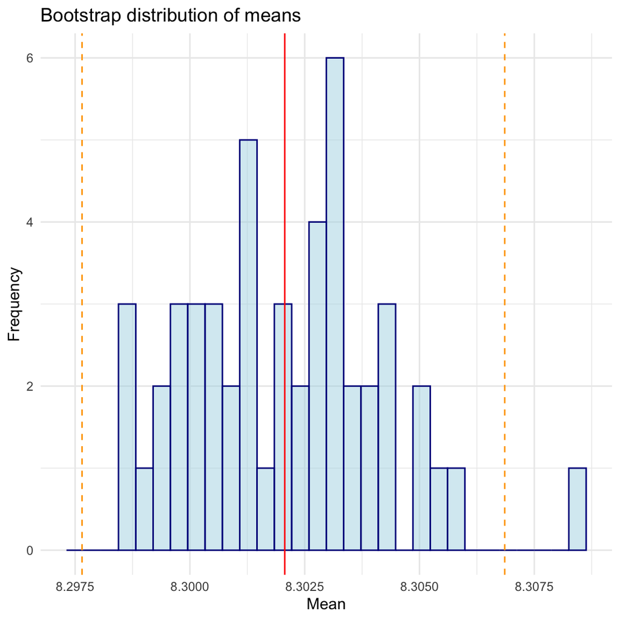

```r
ggplot(data = office_boot, mapping = aes(x = stat)) +
  geom_histogram(color="darkblue", fill="lightblue", alpha = 0.5) +
  geom_vline(xintercept = mean(office_boot$stat), color ="red") +
  geom_vline(xintercept = 8.297651, color ="orange", linetype = "dashed") +
  geom_vline(xintercept = 8.306856, color ="orange", linetype = "dashed") +
labs(title = "Bootstrap distribution of means", x = "Mean", y = "Frequency") +
  theme_minimal()
```

## Exercise 6

Your final task is to interpret what the 95% confidence bounds you calculated mean in the context of The Office’s IMDB Ratings.

ANSWER: We are 95% confident that the true population mean IMDB rating for the office is between 8.297651 and 8.306856

# Bootstrapping a Slope

For the final set of exercises, we will again be using data from The Office.

This time, we are going to bootstrap a slope. Specifically, we will use `imdb_rating` as the DV and `season` as the IV.

## Exercise 7

Fill in the blanks below to successfully create `office_boot_slope`. You will need to take the `theoffice` dataset, specify `imdb_rating` as the response (DV), specify `season` (IV) as the explanatory variable, generate `50` samples, and calculate the `slope`.

```r
set.seed(8888)
# save resulting bootstrap distribution
office_boot_slope <- theoffice %>%
  # specify the variable of interest
  specify(response = imdb_rating,
          explanatory = season) %>%
  # generate 50 bootstrap samples
  generate(reps = 50, type = "bootstrap") %>%
  # calculate the mean of each bootstrap sample
  calculate(stat = "slope")
```

## Exercise 8

How many observations are there in `office_boot`? What does each observation represent?

```r
glimpse(office_boot_slope)
```

```
## Rows: 50
## Columns: 2
## $ replicate <int> 1, 2, 3, 4, 5, 6, 7, 8, 9, 10, 11, 12, 13, 14, 15, 16, 17, 1…
## $ stat      <dbl> -0.08511394, -0.08406704, -0.08385859, -0.08657430, -0.08424…
```

ANSWER: Each observation represents a bootstrapped slope

## Exercise 9

Visualize the bootstrap distribution. Below I have created a basic histogram. Your job is to: Add a theme, use both `color` and `fill` within the `geom_histogram()` function (see links for help), set the histogram `alpha = 0.5`, add a `geom_vline()` that has the value of the slope `office_boot_slope$stat` and give it a `color` (see links below for help), Add a title, make the x axis say `Slope`, and finally make the y axis say `Frequency`.

[**Histogram Help**](http://www.sthda.com/english/wiki/ggplot2-histogram-plot-quick-start-guide-r-software-and-data-visualization#change-histogram-plot-line-types-and-colors)

[**Adding a Vertical Line Help**](https://www.rdocumentation.org/packages/ggplot2/versions/0.9.1/topics/geom_vline)

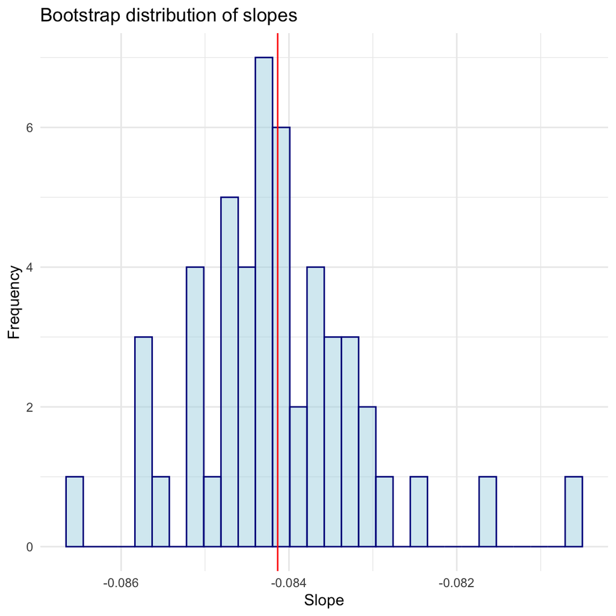

```r
ggplot(data = office_boot_slope, mapping = aes(x = stat)) +
  geom_histogram(color="darkblue", fill="lightblue", alpha = 0.5) +
  geom_vline(xintercept = mean(office_boot_slope$stat), color ="red")+
labs(title = "Bootstrap distribution of slopes", x = "Slope", y = "Frequency") +
  theme_minimal()
```

## Exercise 10

Calculate the confidence interval. A 95% confidence interval is bounded by the middle 95% of the bootstrap distribution. Fill in the values below.

```r
office_boot_slope %>%
  summarize(lower = quantile(stat, 0.025),
            upper = quantile(stat, 0.975))
```

```
## # A tibble: 1 × 2
##     lower   upper
##     <dbl>   <dbl>
## 1 -0.0858 -0.0818
```

## Exercise 11

Copy and paste your histogram code from exercise 3. Your task is to add on an additional 2 lines, one for the lower 95% bound and one for the higher 95% bound. Make the line dashed *and* a different color than your line you already have for the mean.

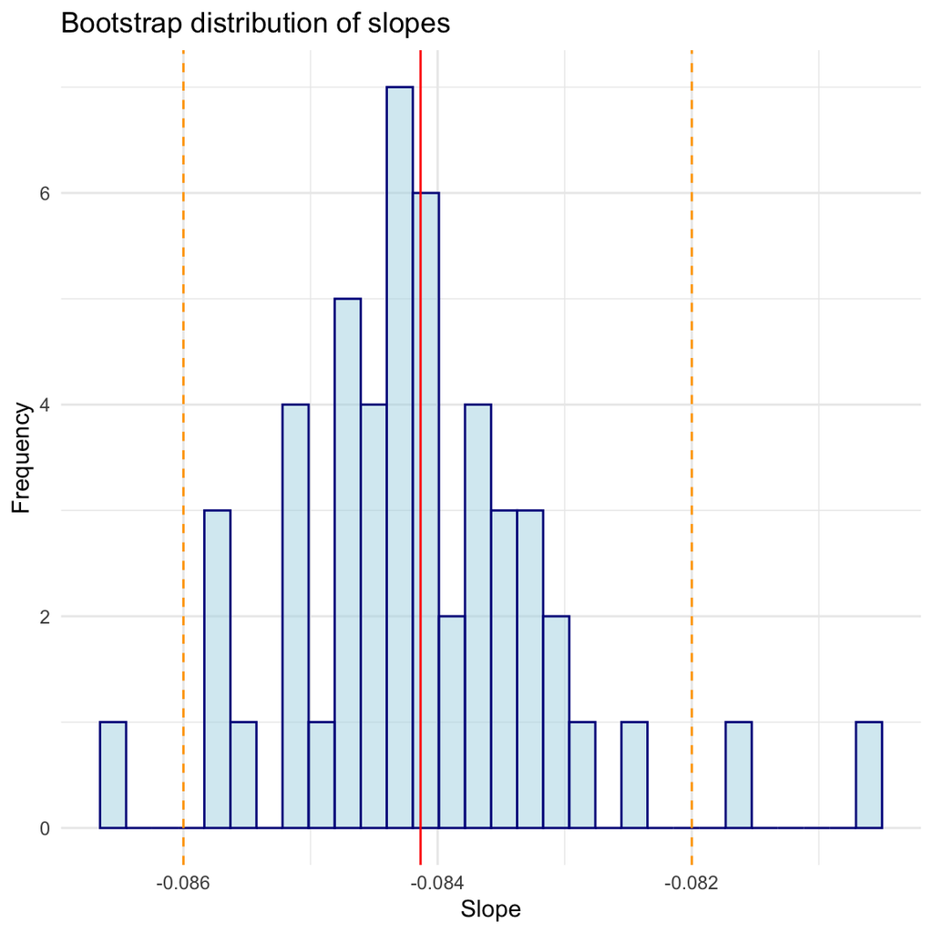

```r
ggplot(data = office_boot_slope, mapping = aes(x = stat)) +
  geom_histogram(color="darkblue", fill="lightblue", alpha = 0.5) +
  geom_vline(xintercept = mean(office_boot_slope$stat), color ="red") +
  geom_vline(xintercept = -0.086, color ="orange", linetype = "dashed") +
  geom_vline(xintercept = -0.082, color ="orange", linetype = "dashed") +
labs(title = "Bootstrap distribution of slopes", x = "Slope", y = "Frequency") +
  theme_minimal()
```

## Exercise 12

Your final task is to interpret what the 95% confidence bounds you calculated mean in the context of regression with The Office’s IMDB Ratings as the DV and season as the IV.

ANSWER: We are 95% confident that the true population slope of the relationship between season predicting imdb ratings is between -0.086 and -0.082.